# Git post-install on Windows

Author

Ed123 Pal

## 1 Introduction

This tutorial is a follow-on to the Git Install tutorial.

In this tutorial, you’ll learn how to find artifacts regarding the Git install on your computer. This learning will help you to verify the Git installation and provide information that could be useful as you work with Git in the future.

## 2 Learning Objectives

After completing this tutorial, you should be able to: See what Git options have been added to the Start menu. Find Git on the Control Panel. Find Git on the Path environment variable. Find Git version. Find where Git is installed on the hard drive. Find the Git system configuration file.

## 3 Start Menu

This is what the Start menu looks like when Git is installed:

[figure not shown]

## 4 Control Panel

This is what the Uninstall or change a program screen looks like when Git is installed.

[figure not shown]

**Note**

If you install a newer version of Git in the future, a good practice is to uninstall Git before installing the newer version. If you do so, refer to the Git Uninstall tutorial because there more to do in addition to using the Uninstall option shown on the Control Panel.

## 5 File System

### 5.1 Program Files

The default location for install Git is the Program Files\Git folder.

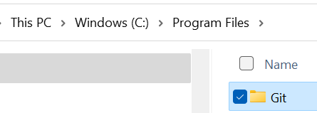

## 6 where command

Using the where command in the Command Prompt window will display the location of the Git folder.

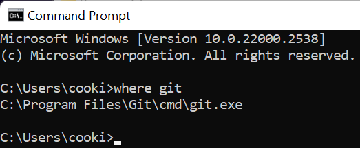

## 7 Path Variable

Examine the contents of the Path environment variable to confirm it contains the directory path to the Git\cmd folder.

The Git executable file (git.exe) is located in the Git\cmd folder. When you run any git command such as git status, the git executable is invoked and the argument(s) such as “status” are passed to Git.

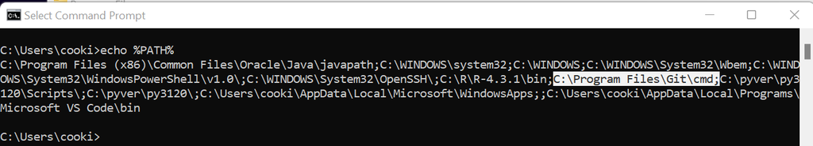

## 8 Git Version

Using a Command Prompt window, invoke the Git executable and pass the “--version” argument. Git will return the Git version.

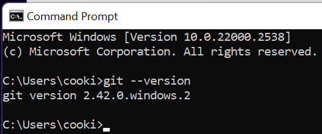

## 9 Configuration Files

**Note**

Now is a good time to review the Git pre-install tutorial section about the Git configuration files. This section explains the purpose and relationship between the system, global and local configuration files.

### 9.1 System config

The location for Git system configuration file is located as shown below. See the Date modified is when Git was installed, i.e. the system config file is created along with the installation of Git.

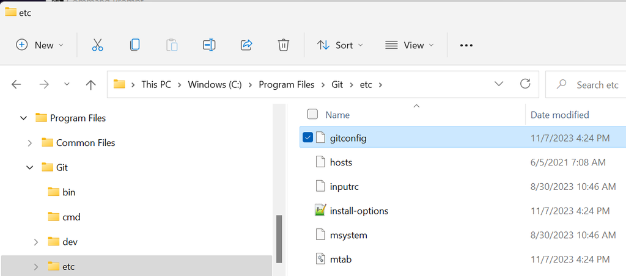

The screenshot just below shows the contents of the system config file right after Git was installed.

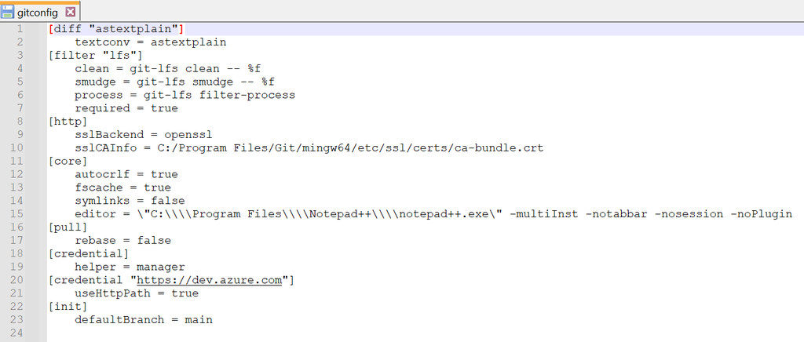

The screenshot just below shows what’s display when running the git config “--” command. You can see the results of this command align with the contents of the system config file.

**Note**

The double quotation marks around the two dashes should not be typed when entering and running the git config command. The quotation marks are used above because the Quarto editor will fuse the two dashes into a single long dash if I don’t surround the two adjacent dashes with quotation marks.

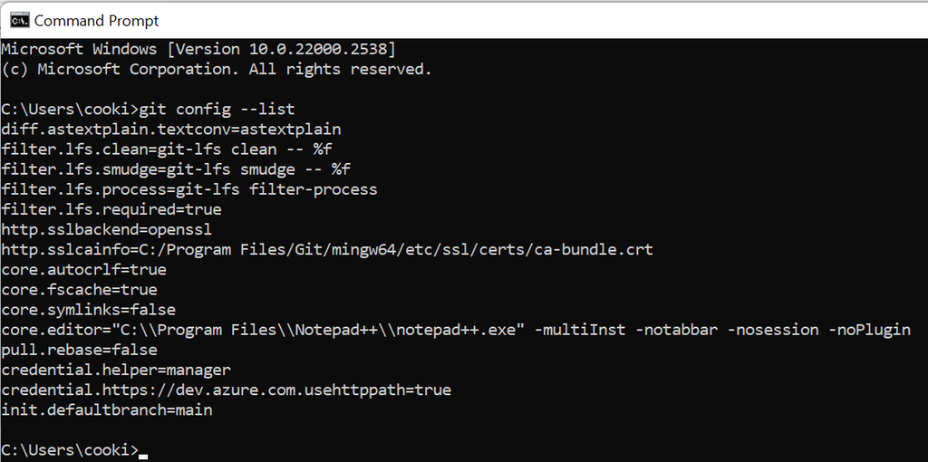

**Note**

Typically there’s no need to change the contents of the system config file. An example of when you might do so is to change the default editor to another text editor program that’s on your computer.

### 9.2 Global config

The global config file is not created when Git is installed.

The screenshot just below shows issuing a git configuration command to change a global configuration. In these case, the user.name is being set at the global level.

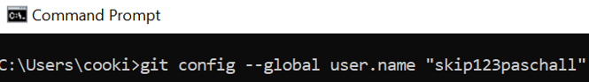

By issuing the git config “--” global user.name “skip123paschall” then Git will create a global config file that contains a line specifying the global configuration for the user.name.

Once the above git config command is executed there will be a Git global config file located in the following location: C:\Users\username\.gitconfig.

The contents of the Git global config file contains just one item since there’s just been a single git config “--” global command entered after Git was installed.

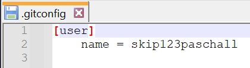

The screenshot below showing the output from again issuing the git config “--” list command. It’s the same as seen in the above System config section except now there is a line for user.name.

Just be looking at this output, you cannot tell the user.name was configured by git config “--” global. To find out you’d needed to look at the contents of the system or global config files.

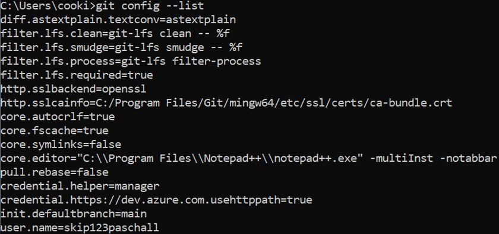

**Note**

Git configuration files are plain text files that can be modified with a text editor. However, the best practice is to use the git config command, which then will update the appropriate configuration file. This approach helps to avoid making an unintended change to another line in the config file or making a syntax error when editing the file.

**Note**

Nothing has been said so far about the local config file. That’s because no project has been put under Git version control since Git was installed on this computer. The local Git config file is only available in the .git folder of a project that is using Git. There will be more information about local config files in the Using Git 1st Time tutorial.

### 9.3 Global config 2

This Global config 2 section is similar to the prior section except it just briefly shows how to configure the user.email, which is done just like configuring user.name.

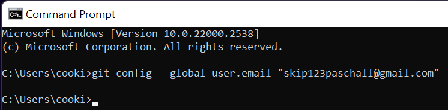

Issuing the git config command following by a specific configuration email will show the value that Git will use when it needs that specific element.

[figure not shown]

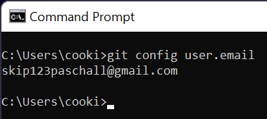

**Note**

Recall if a config element is specified at the local (i.e. project level) the value configured at that level will be used by Git when it’s working with that project. If a specific element is not configured at the local level, then Git will use the value if it’s configured at the global level. If it’s not configured at the global level then Git will finally check to see if it has a value configured in the system config file.

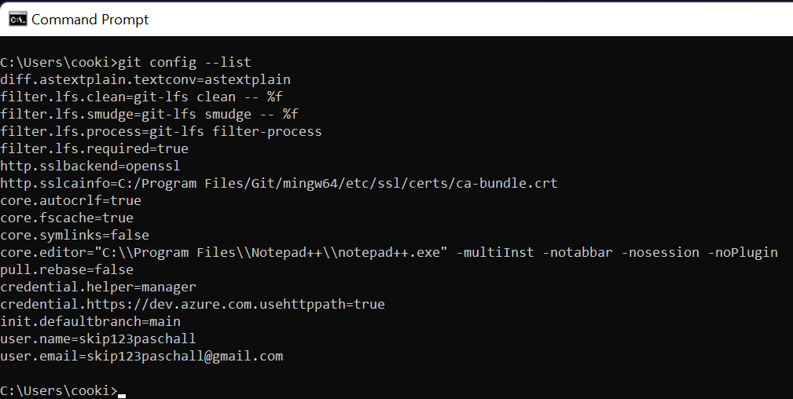

[figure not shown]

## 10 Wrap Up

### 10.1 Congratulations!

You’ve completed this tutorial and should now be able to identify key Git artifacts about how Git was installed on your computer.

### 10.2 What’s next?

Now your ready to use Git for a project. See the Using Git 1st Time tutorial.

**Note**

Using Git to perform version control on a project is often referred to as “putting a project under version control”. See this [ChatGPT link](https://chat.openai.com/c/b619ab33-eb06-4b3c-b800-513af4280265) for more information.